# Reproducible Research: Peer Assessment 1

## Introduction

It is now possible to collect a large amount of data about personal movement using activity monitoring devices such as a [Fitbit](http://www.fitbit.com), [Nike Fuelband](http://www.nike.com/us/en_us/c/nikeplus-fuelband), or [Jawbone Up](https://jawbone.com/up). These type of devices are part of the “quantified self” movement – a group of enthusiasts who take measurements about themselves regularly to improve their health, to find patterns in their behavior, or because they are tech geeks. But these data remain under-utilized both because the raw data are hard to obtain and there is a lack of statistical methods and software for processing and interpreting the data.

This assignment makes use of data from a personal activity monitoring device. This device collects data at 5 minute intervals through out the day. The data consists of two months of data from an anonymous individual collected during the months of October and November, 2012 and include the number of steps taken in 5 minute intervals each day.

## Data

The data for this assignment can be downloaded from the course web site:

- Dataset: [Activity monitoring data](https://d396qusza40orc.cloudfront.net/repdata%2Fdata%2Factivity.zip) [52K]

The variables included in this dataset are:

- **steps**: Number of steps taking in a 5-minute interval (missing values are coded as `NA`)
- **date**: The date on which the measurement was taken in YYYY-MM-DD format
- **interval**: Identifier for the 5-minute interval in which measurement was taken

The dataset is stored in a comma-separated-value (CSV) file and there are a total of 17,568 observations in this dataset.

## Loading and preprocessing the data

```r
activity<-readr::read_delim("activity.zip",delim = ",")
```

## What is mean total number of steps taken per day?

How many steps is taken per day? As we can see on histogram below most frequenty it’s between 10000 and 15000 steps per day.

```r
library(dplyr)
  total_steps_day<-activity %>% select(steps,date) %>% group_by(date) %>% summarize(steps=sum(steps,na.rm=TRUE))


  total_steps_day_mean<-total_steps_day%>%ungroup() %>% summarize(mean_steps_per_day=mean(steps,na.rm=TRUE))

  total_steps_day_median<-total_steps_day%>%ungroup() %>% summarize(median_steps_per_day=median(steps,na.rm=TRUE))
```

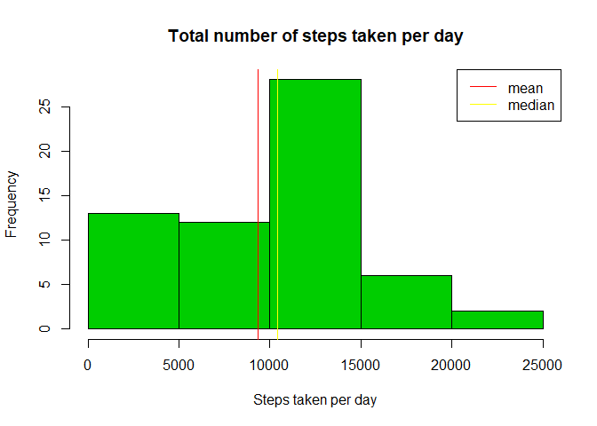

```r
  hist(total_steps_day$steps, main ="Total number of steps taken per day", xlab = "Steps taken per day",freq = TRUE,col = 3 )

  abline(v = total_steps_day_mean$mean_steps_per_day, col = 2)

  abline(v = total_steps_day_median$median_steps_per_day, col = 7)
  legend("topright",legend = c("mean","median"),col = c(2,7),lty = 1)
```

## What is the average daily activity pattern?

During day activity differs so we should expect that nubers of steps would be different for different parts of day. On plot below we see average activity pattern in 5 minutes intervals during the day.

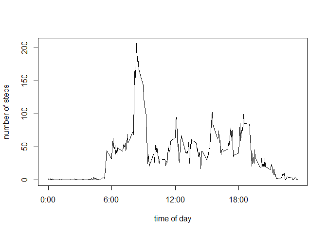

```r
average_steps_interval <- activity %>% select(steps, interval) %>% group_by(interval) %>% summarize(steps = mean(steps, na.rm = TRUE))


plot(x = average_steps_interval$interval , y = average_steps_interval$steps, type = "l", xlab = "time of day", ylab = "number of steps",xaxt="n")
axis(1, at=c(0,600,1200,1800), labels=c("0:00","6:00","12:00","18:00"))
```

```r
maxinterval<-average_steps_interval %>% ungroup() %>% mutate(stepsmax =  max(steps)) %>% filter(steps == stepsmax)


xtimemax<- sprintf("%04d", maxinterval$interval)
htimemax <-substr(xtimemax,1,2)
mtimemax<-substr(xtimemax,3,4)

timemax<-paste0(htimemax,':',mtimemax)
```

In our dataset most steps are made during 08:35 interval and it’s 206.1698113 steps.

## Imputing missing values

Unfortunately our data has missing values.

```r
missing_values_sum<-sum(is.na(activity$steps))
```

To be specific we have 2304 missing values. Let’s replace them by mean of steps for corresponding interval.

```r
activityfull<-activity %>% mutate(steps=ifelse(is.na(steps),average_steps_interval$steps,steps))
```

Once again let’s look for histogram of total numbers of steps taken per day. This time for data without missing values.

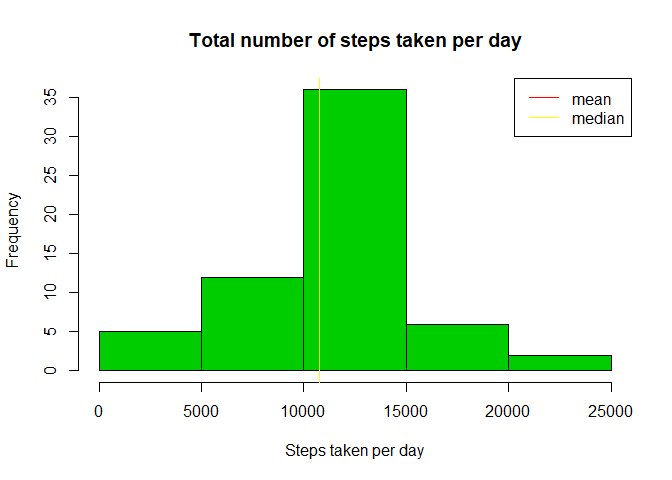

```r
  total_steps_day_f<-activityfull %>% select(steps,date) %>% group_by(date) %>% summarize(steps=sum(steps,na.rm=TRUE))
  hist(total_steps_day_f$steps, main ="Total number of steps taken per day", xlab = "Steps taken per day",freq = TRUE,col = 3 )
  total_steps_day_mean_f<-total_steps_day_f%>%ungroup() %>% summarize(mean_steps_per_day=mean(steps,na.rm=TRUE))

  abline(v = total_steps_day_mean_f$mean_steps_per_day, col = 2)

total_steps_day_median_f<-total_steps_day_f%>%ungroup() %>% summarize(median_steps_per_day=median(steps,na.rm=TRUE))

  abline(v = total_steps_day_median_f$median_steps_per_day, col = 7)

  legend("topright",legend = c("mean","median"),col = c(2,7),lty = 1)
```

## Are there differences in activity patterns between weekdays and weekends?

People behave differently on weekdays and weekends. Let’s see if the activity pattern for those days is different.

```r
Sys.setlocale(category = "LC_ALL", locale = "English_United States.1252")
```

```
## [1] "LC_COLLATE=English_United States.1252;LC_CTYPE=English_United States.1252;LC_MONETARY=English_United States.1252;LC_NUMERIC=C;LC_TIME=English_United States.1252"
```

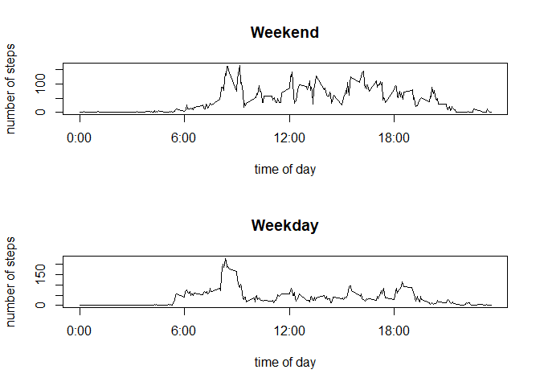

```r
weekday<-weekdays(activityfull$date)
activityfullweekends<-activityfull%>%filter(weekdays(activityfull$date) %in% c("Saturday", "Sunday"))
activityfullworkdays<-activityfull%>%filter(!(weekdays(activityfull$date) %in% c("Saturday", "Sunday")))


av_steps_interval_weekends <- activityfullweekends %>% select(steps, interval) %>% group_by(interval) %>% summarize(steps = mean(steps, na.rm = TRUE))


av_steps_interval_workdays <- activityfullworkdays %>% select(steps, interval) %>% group_by(interval) %>% summarize(steps = mean(steps, na.rm = TRUE))


par(mfrow = c(2,1))



plot(x = av_steps_interval_weekends$interval , y = av_steps_interval_weekends$steps, type = "l",main = "Weekend", xlab = "time of day", ylab = "number of steps",xaxt="n")
axis(1, at=c(0,600,1200,1800), labels=c("0:00","6:00","12:00","18:00"))





plot(x = av_steps_interval_workdays$interval , y = av_steps_interval_workdays$steps, type = "l",main ="Weekday", xlab = "time of day", ylab = "number of steps",xaxt="n")
axis(1, at=c(0,600,1200,1800), labels=c("0:00","6:00","12:00","18:00"))
```

We can see that on weekends the number of steps during all day is less variable. On weekday we can observe peak about 8:30 and a smaller one after 18:00.